# Exercise solutions: Section 12.6

Rob J Hyndman and George Athanasopoulos

# fpp3 12.6, Ex 1

> Compare STL and Dynamic Harmonic Regression forecasts for one of the series in the `pedestrian` data set.
> 1. Try modifying the order of the Fourier terms to minimize the AICc value.

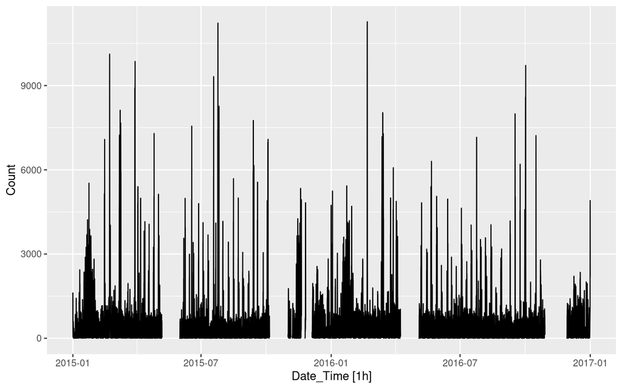

```r
# Extract data from one sensor
bm <- pedestrian %>%
  filter(Sensor == "Birrarung Marr")
bm %>% fill_gaps() %>% autoplot(Count)
```

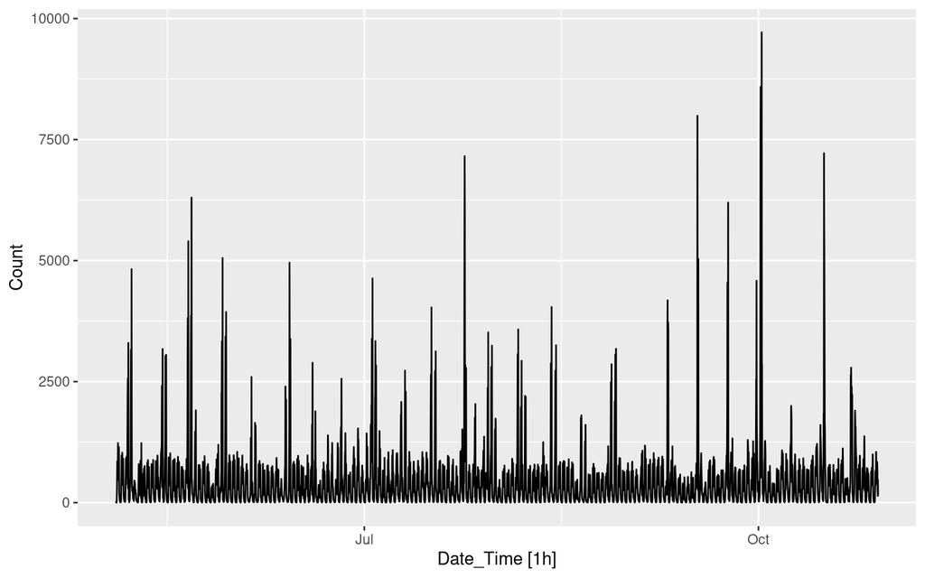

```r
# Select longest series of non-missing values
long_section <- bm %>%
  mutate(gap = Date_Time - lag(Date_Time)) %>%
  filter(gap > 24) %>%
  tail(2) %>%
  pull(Date_Time)
bm <- bm %>%
  filter(Date_Time >= long_section[1], Date_Time < long_section[2]) %>%
  fill_gaps()
bm %>% autoplot(Count)
```

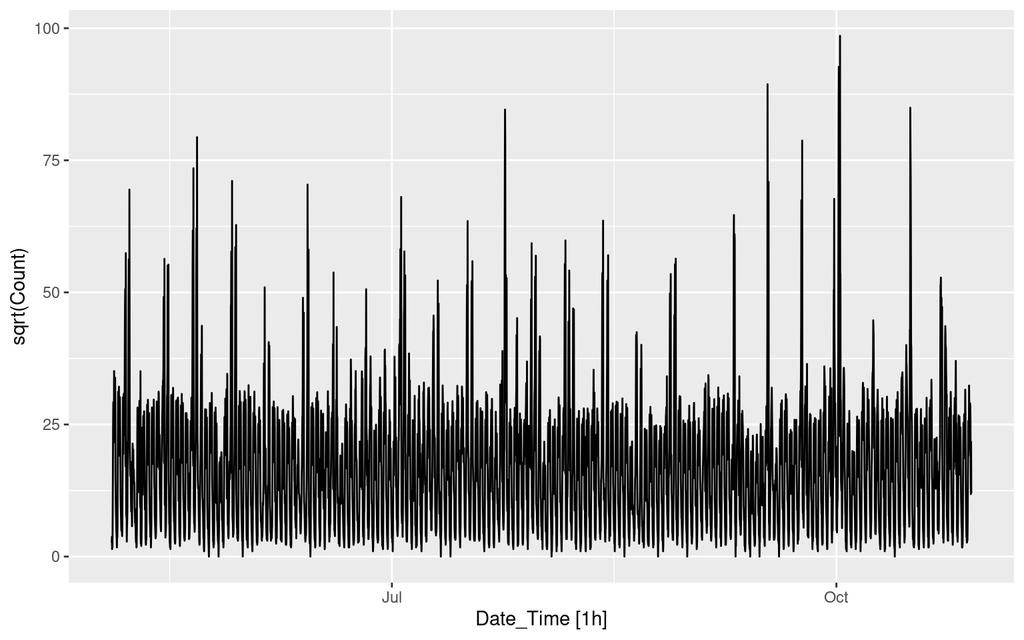

```r
bm %>% autoplot(sqrt(Count))
```

```r
fit <- bm %>%
  model(
    stlarima = decomposition_model(STL(sqrt(Count)), ARIMA(season_adjust ~ PDQ(0,0,0))),
    dhr = ARIMA(sqrt(Count) ~ fourier(period="day", K=12) + fourier(period="week", K=10) + PDQ(0,0,0)),
  )
```

> 2. Check the residuals for each model. Do they capture the available information in the data?

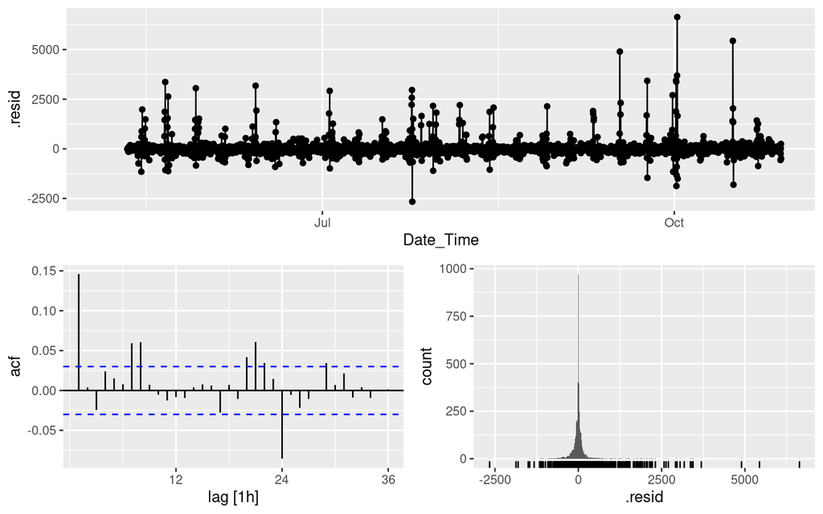

```r
fit %>%
  select(stlarima) %>%
  gg_tsresiduals()
```

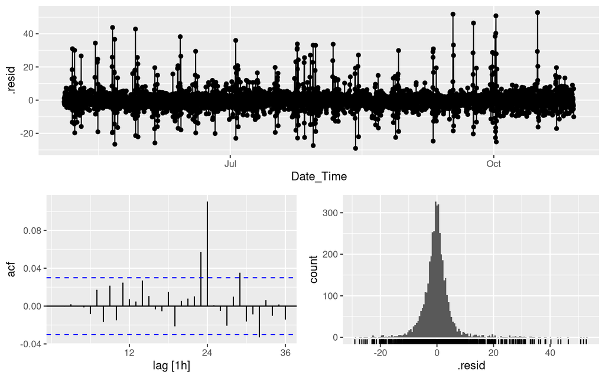

```r
fit %>%
  select(dhr) %>%
  gg_tsresiduals()
```

This is a little misleading as the STL-ARIMA residuals are on the original scale of the data, while those from the DHR model are on the transformed data. Nevertheless, the DHR handles the short-term correlations in the data much better than the STLETS model. There is still some 24-hour autocorrelation that is not being adequately handled by DHR, although the size of the autocorrelation is only about 0.1, so can probably be safely ignored.

> 3. Which of the two sets of forecasts are best? Explain.

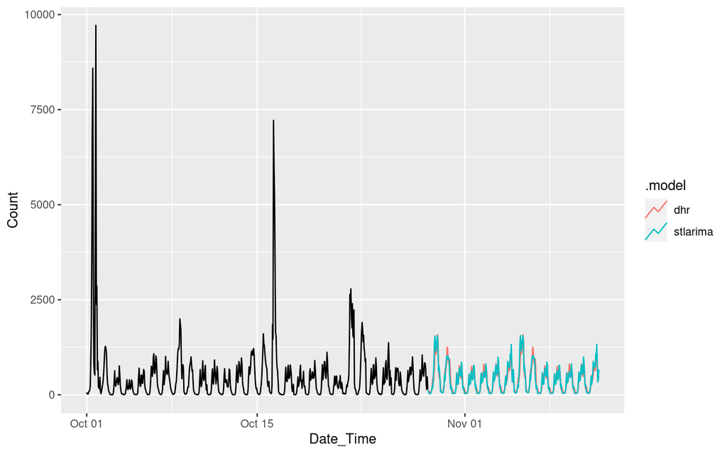

```r
fit %>%
  forecast(h = "2 weeks") %>%
  autoplot(bm %>% filter(Date >= "2016-10-01"), level=NULL)
```

The forecasts are very similar.

# fpp3 12.6, Ex 2

> Consider the weekly data on US finished motor gasoline products supplied (millions of barrels per day) (series `us_gasoline`):
> 1. Fit a dynamic harmonic regression model to these data. How does it compare to the regression model you fitted in Exercise 5 in Section 7.10?

```r
gas <- us_gasoline %>% filter(year(Week) <= 2004)
fit <- gas %>%
  model(
    fourier7 = TSLM(Barrels ~ trend() + fourier(K = 7)),
    dhm = ARIMA(Barrels ~ trend() + fourier(K=7) + PDQ(0,0,0))
  )
fit
```

```
## # A mable: 1 x 2
##   fourier7                         dhm
##    <model>                     <model>
## 1   <TSLM> <LM w/ ARIMA(0,0,1) errors>
```

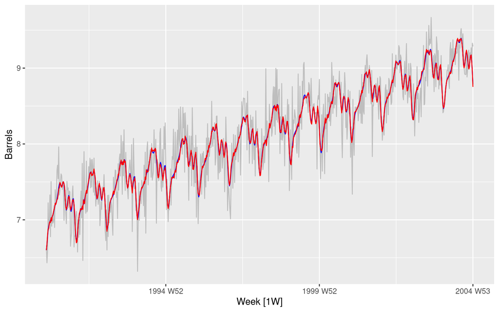

```r
gas %>%
  autoplot(Barrels, col = "gray") +
  geom_line(
    data = augment(fit) %>% filter(.model == "fourier7"),
    aes(y = .fitted), col = "blue"
  ) +
  geom_line(
    data = augment(fit) %>% filter(.model == "dhm"),
    aes(y = .fitted), col = "red"
  )
```

```r
fit %>% forecast(h=6)
```

```
## # A fable: 12 x 4 [1W]
## # Key:     .model [2]
##    .model       Week       Barrels .mean
##    <chr>      <week>        <dist> <dbl>
##  1 fourier7 2005 W01 N(8.7, 0.074)  8.66
##  2 fourier7 2005 W02 N(8.6, 0.074)  8.61
##  3 fourier7 2005 W03 N(8.6, 0.074)  8.64
##  4 fourier7 2005 W04 N(8.7, 0.074)  8.72
##  5 fourier7 2005 W05 N(8.8, 0.074)  8.81
##  6 fourier7 2005 W06 N(8.9, 0.074)  8.90
##  7 dhm      2005 W01 N(8.6, 0.072)  8.62
##  8 dhm      2005 W02 N(8.6, 0.073)  8.61
##  9 dhm      2005 W03 N(8.6, 0.073)  8.64
## 10 dhm      2005 W04 N(8.7, 0.073)  8.72
## 11 dhm      2005 W05 N(8.8, 0.073)  8.81
## 12 dhm      2005 W06 N(8.9, 0.073)  8.90
```

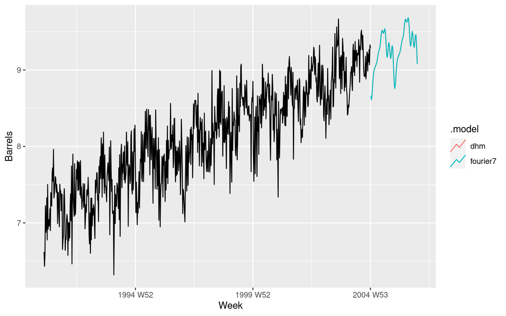

```r
fit %>%
  forecast(h="2 years") %>%
  autoplot(gas, level=NULL)
```

These two models are almost identical. The additional MA(1) parameter in the DHM only affects the first point forecast, and leads to slightly narrower the prediction intervals.

> 2. Check the residuals from both models and comment on what you see.

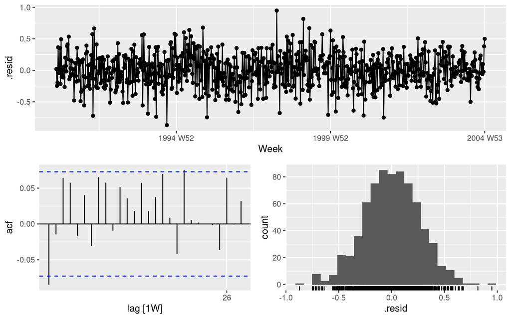

```r
fit %>%
  select(fourier7) %>%
  gg_tsresiduals()
```

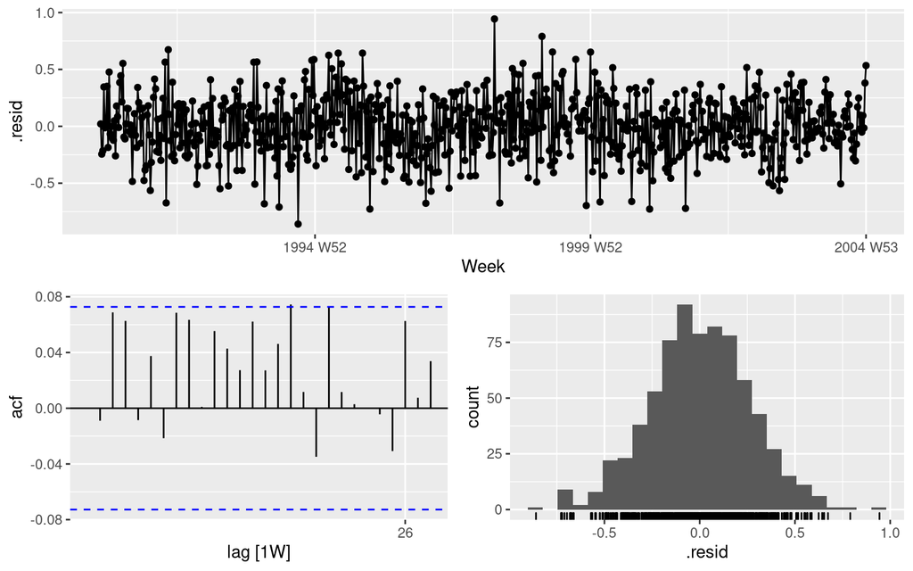

```r
fit %>%
  select(dhm) %>%
  gg_tsresiduals()
```

The tiny spike at lag 1 in the ACF of the regression model is corrected in the DHM model.

> 3. Could you model these data using any of the other methods we have considered in this book? Explain why/why not.

You could also use an STL decomposition followed by an ETS or ARIMA on the seasonally adjusted data. You couldn’t use an ETS directly as the seasonal period is too long and non-integer. You could try a seasonal ARIMA model with an approximate seasonal period of 52, but this is unlikely to work well with such a large seasonal period.

# fpp3 12.6, Ex 3

> Experiment with using `NNETAR()` on your retail data and other data we have considered in previous chapters.

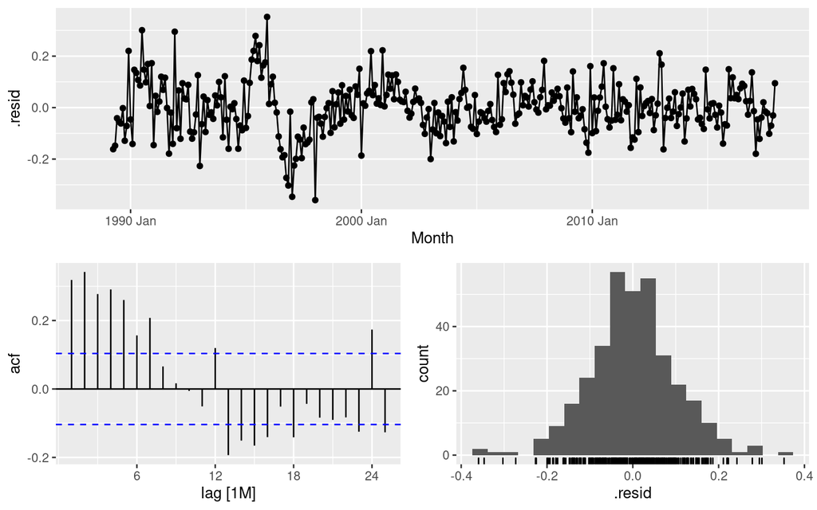

```r
set.seed(12345678)
myseries <- aus_retail %>%
  filter(
    `Series ID` == sample(aus_retail$`Series ID`, 1),
    year(Month) < 2018
  )
fit <- myseries %>%
  model(
    ets = ETS(Turnover),
    arima = ARIMA(log(Turnover)),
    nnetar = NNETAR(log(Turnover))
  )
fit %>% select(nnetar) %>% gg_tsresiduals()
```

The residuals from the NNETAR model have a lot of autocorrelations remaining.

```r
fit %>%
  forecast(h = "3 years") %>%
  accuracy(aus_retail)
```

```
## # A tibble: 3 x 12
##   .model State Industry .type      ME  RMSE   MAE    MPE  MAPE  MASE RMSSE  ACF1
##   <chr>  <chr> <chr>    <chr>   <dbl> <dbl> <dbl>  <dbl> <dbl> <dbl> <dbl> <dbl>
## 1 arima  Nort… Clothin… Test  -1.14   1.41  1.14  -7.71   7.71 1.30  1.21  0.212
## 2 ets    Nort… Clothin… Test  -0.718  0.967 0.777 -4.84   5.27 0.883 0.830 0.149
## 3 nnetar Nort… Clothin… Test   0.0493 1.05  0.969 -0.395  7.12 1.10  0.903 0.670
```

The NNETAR model provides better forecasts for 2018 than the ARIMA model, but not as well as the ETS model.